# 7 - Neural networks as function approximators

Martha felt that the biological metaphors left something missing, and in her notes (section 7.6) she describes neural networks as what they are mathematically: **function approximators** that combine simple building blocks, **basis functions**. The **universal approximation theorem** says that a network with a single, wide enough hidden layer can approximate any continuous function on a bounded interval as closely as we want. In this notebook we see why, with ReLU neurons:

1. Import the libraries.
2. The building block: a ReLU as a hinged ruler.
3. Adding hinges: piecewise-linear approximations.
4. Letting a network choose where to put the hinges.
5. Why depth helps.

### Step 1: Import the libraries

```python
import numpy as np
import matplotlib.pyplot as plt

np.set_printoptions(precision=3, suppress=True)

def relu(z):
    return np.maximum(0, z)
```

### Step 2: A ReLU as a hinged ruler

A shifted and scaled ReLU, $c \cdot \text{ReLU}(x - b)$, is what Martha calls a **hinged ruler**: it lies flat on the axis until the point $x = b$ (the **kink**), and from there on it is a straight line with slope $c$.

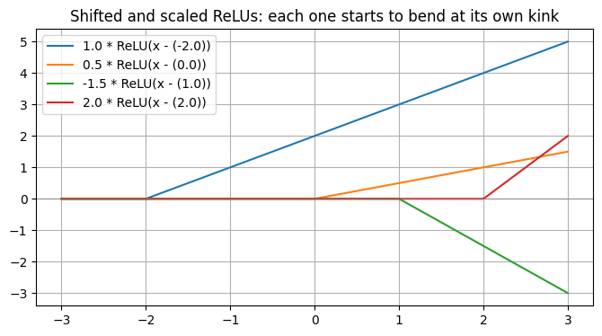

```python
x = np.linspace(-3, 3, 400)
plt.figure(figsize=(8, 4))
for c, b in [(1.0, -2.0), (0.5, 0.0), (-1.5, 1.0), (2.0, 2.0)]:
    plt.plot(x, c * relu(x - b), label=f'{c} * ReLU(x - ({b}))')
plt.axhline(0, color='gray', linewidth=0.5)
plt.title('Shifted and scaled ReLUs: each one starts to bend at its own kink')
plt.legend()
plt.grid(True)
plt.show()
```

### Step 3: Adding hinges

Adding several hinges, $\hat{f}(x) = \sum_i c_i \,\text{ReLU}(x - b_i)$ (plus a straight line), gives a **continuous piecewise-linear** curve: between two consecutive kinks the slope is constant, and at each kink $b_i$ it changes by exactly $c_i$. With more kinks we get more, shorter segments, and we can trace a smooth curve as closely as we want.

We try it with a curvy target function, $f(x) = \sin(2x) + 0.3x^2$. We place the kinks evenly and compute the best coefficients $c_i$ by least squares (the same method as linear regression in chapter 2):

```
 3 hinges: root mean squared error 0.5228, largest error 1.1246
 6 hinges: root mean squared error 0.1022, largest error 0.2371
12 hinges: root mean squared error 0.0254, largest error 0.0750
24 hinges: root mean squared error 0.0065, largest error 0.0210
```

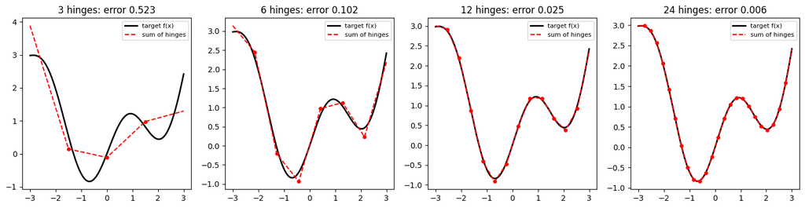

```
With 6 hinges, slope change at each kink: [-2.3    2.259  3.069 -2.04  -1.231  3.333]
Coefficients c_i of the hinges:           [-2.3    2.259  3.069 -2.04  -1.231  3.333]
```

```python
target = np.sin(2 * x) + 0.3 * x ** 2

def fit_hinges(n_kinks):
    kinks = np.linspace(-3, 3, n_kinks + 2)[1:-1]
    A = np.c_[np.ones_like(x), x, relu(x[:, None] - kinks[None, :])]      # a straight line + one column per hinge
    coef, *_ = np.linalg.lstsq(A, target, rcond=None)
    return kinks, coef, A @ coef

fig, axes = plt.subplots(1, 4, figsize=(18, 4))
for ax, n in zip(axes, [3, 6, 12, 24]):
    kinks, coef, approx = fit_hinges(n)
    rmse = np.sqrt(np.mean((approx - target) ** 2))
    print(f"{n:>2} hinges: root mean squared error {rmse:.4f}, largest error {np.max(np.abs(approx - target)):.4f}")
    ax.plot(x, target, 'k', linewidth=2, label='target f(x)')
    ax.plot(x, approx, 'r--', label='sum of hinges')
    ax.plot(kinks, np.interp(kinks, x, approx), 'ro', markersize=4)
    ax.set_title(f'{n} hinges: error {rmse:.3f}')
    ax.legend(fontsize=8)
plt.show()

kinks, coef, approx = fit_hinges(6)
slope = np.diff(approx) / np.diff(x)
jumps = [slope[np.searchsorted(x, b) + 2] - slope[np.searchsorted(x, b) - 2] for b in kinks]
print(f"\nWith 6 hinges, slope change at each kink: {np.round(jumps, 3)}")
print(f"Coefficients c_i of the hinges:           {np.round(coef[2:], 3)}")
```

Each time we double the number of hinges, the error falls by about four: from 0.52 with 3 hinges to 0.0065 with 24, where the approximation is hard to tell apart from the curve. And the slope of the approximation changes at each kink by exactly the coefficient $c_i$ of its hinge, as Martha's formula says.

### Step 4: Letting a network choose the hinges

A neural network with one hidden layer of ReLU neurons computes exactly this kind of sum: each hidden neuron $\text{ReLU}(w_i x + b_i)$ is a hinge with its kink at $x = -b_i / w_i$, and the output layer adds them up with weights $a_i$. The difference is that the network also **learns where to put the kinks**. We train a network with 12 hidden neurons, minimizing the mean squared error with the **Adam** optimizer (gradient descent with an adaptive step), from 6 different random starts:

```
Start 0: root mean squared error 0.0505
Start 1: root mean squared error 0.0358
Start 2: root mean squared error 0.0438
Start 3: root mean squared error 0.1602
Start 4: root mean squared error 0.0333
Start 5: root mean squared error 0.0425

Best network: error 0.0333, kinks inside [-3, 3]: [-2.276 -1.118 -0.826 -0.771 -0.758 -0.715 -0.417  0.567  0.995  2.028
  2.495]
```

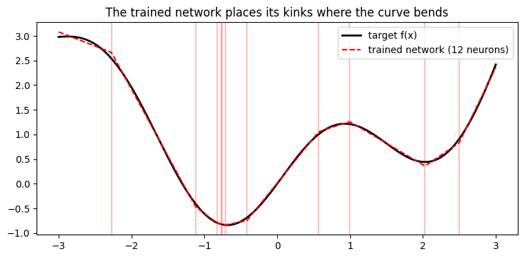

```python
def train_network(seed, hidden=12, learning_rate=0.01, steps=20000):
    rng = np.random.default_rng(seed)
    w = rng.choice([-1, 1], hidden) * rng.uniform(0.5, 1.5, hidden)
    params = [w, -w * rng.uniform(-3, 3, hidden), rng.normal(0, 0.1, hidden), np.zeros(1)]   # kinks start spread out
    m, v = [np.zeros_like(p) for p in params], [np.zeros_like(p) for p in params]
    for t in range(1, steps + 1):
        z = x[:, None] * params[0] + params[1]
        h = relu(z)                                          # hidden layer: one hinge per neuron
        error = h @ params[2] + params[3][0] - target
        d_out = 2 * error / len(x)
        d_hidden = d_out[:, None] * params[2] * (z > 0)     # backpropagation through the ReLU
        grads = [(d_hidden * x[:, None]).sum(axis=0), d_hidden.sum(axis=0), h.T @ d_out, np.array([d_out.sum()])]
        for i, g in enumerate(grads):                        # Adam update
            m[i] = 0.9 * m[i] + 0.1 * g
            v[i] = 0.999 * v[i] + 0.001 * g ** 2
            params[i] -= learning_rate * (m[i] / (1 - 0.9 ** t)) / (np.sqrt(v[i] / (1 - 0.999 ** t)) + 1e-8)
    return np.sqrt(np.mean(error ** 2)), params

runs = [train_network(seed) for seed in range(6)]
for seed, (rmse, _) in enumerate(runs):
    print(f"Start {seed}: root mean squared error {rmse:.4f}")

best_rmse, (w, b, a, c) = min(runs, key=lambda r: r[0])
learned_kinks = np.sort((-b / w)[(-b / w > -3) & (-b / w < 3)])
print(f"\nBest network: error {best_rmse:.4f}, kinks inside [-3, 3]: {learned_kinks}")

approx = relu(x[:, None] * w + b) @ a + c[0]
plt.figure(figsize=(9, 4))
plt.plot(x, target, 'k', linewidth=2, label='target f(x)')
plt.plot(x, approx, 'r--', label='trained network (12 neurons)')
for k in learned_kinks:
    plt.axvline(k, color='red', alpha=0.25)
plt.title('The trained network places its kinks where the curve bends')
plt.legend()
plt.show()
```

### Step 5: Why depth helps

Martha adds that, although one layer is enough in theory, deep networks are far more efficient in practice: each layer transforms the output of the previous one. A classic example makes this concrete. A layer of just **2 ReLU neurons** can build a "tent" on the interval $[0, 1]$, $t(x) = 2\,\text{ReLU}(x) - 4\,\text{ReLU}(x - 0.5)$, which goes up and then down. Stacking the same layer $L$ times folds the interval again and again. We count the linear pieces of the result:

```
1 layer(s) of 2 neurons =  2 neurons:   2 linear pieces
2 layer(s) of 2 neurons =  4 neurons:   4 linear pieces
3 layer(s) of 2 neurons =  6 neurons:   8 linear pieces
4 layer(s) of 2 neurons =  8 neurons:  16 linear pieces
5 layer(s) of 2 neurons = 10 neurons:  32 linear pieces
6 layer(s) of 2 neurons = 12 neurons:  64 linear pieces
7 layer(s) of 2 neurons = 14 neurons: 128 linear pieces
8 layer(s) of 2 neurons = 16 neurons: 256 linear pieces
```

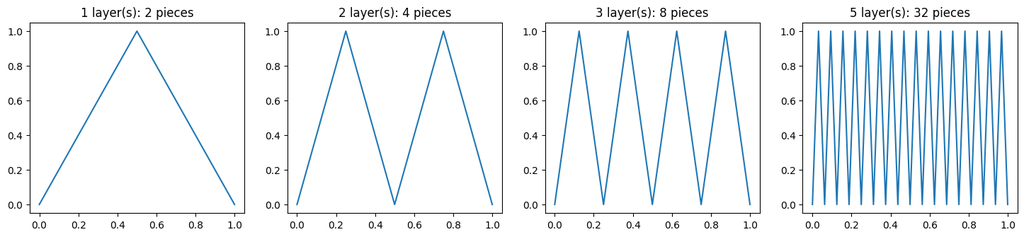

```python
def tent(u):
    return 2 * relu(u) - 4 * relu(u - 0.5)                       # a layer of 2 ReLU neurons

u = np.linspace(0, 1, 2 ** 12 + 1)                            # the kinks fall exactly on grid points
fig, axes = plt.subplots(1, 4, figsize=(18, 3.5))
y = u
for depth in range(1, 9):
    y = tent(y)
    slopes = np.round(np.diff(y) / np.diff(u), 3)
    pieces = 1 + np.count_nonzero(np.diff(slopes))
    print(f"{depth} layer(s) of 2 neurons = {2 * depth:>2} neurons: {pieces:>3} linear pieces")
    if depth in (1, 2, 3, 5):
        ax = axes[[1, 2, 3, 5].index(depth)]
        ax.plot(u, y)
        ax.set_title(f'{depth} layer(s): {pieces} pieces')
plt.show()
```

Each new layer of just 2 neurons doubles the number of linear pieces: 16 neurons in 8 layers produce 256 pieces. A network with a single hidden layer has at most one kink per neuron, so it would need about 255 neurons to build the same shape. That is Martha's point: composing simple transformations, one after another, is far more efficient than placing them side by side.

### Conclusion

- A ReLU neuron is a **hinged ruler**, and a sum of them is a continuous piecewise-linear curve that can follow any continuous function as closely as we want, if we add enough hinges. That is the idea behind the **universal approximation theorem**.
- The theorem guarantees that a good approximation *exists*, but not that training will *find* it: one of our starts got stuck with a clearly worse result.
- A trained network learns both where to place its kinks and how much each one bends the curve, and it places them where the function changes most.
- **Depth** composes transformations: with a few neurons per layer, each new layer can multiply the number of linear pieces. This is one reason why deep networks capture complex patterns with fewer parameters than shallow ones.
- Language models are, at bottom, enormous function approximators of this kind: they map a sequence of tokens to the probabilities of the next one.